# Определение перспективного тарифа для телеком-компании

Вы аналитик компании «Мегалайн» — федерального оператора сотовой связи. Клиентам предлагают два тарифных плана: «Смарт» и «Ультра». Чтобы скорректировать рекламный бюджет, коммерческий департамент хочет понять, какой тариф приносит больше денег. Вам предстоит сделать предварительный анализ тарифов на небольшой выборке клиентов. В вашем распоряжении данные 500 пользователей «Мегалайна»: кто они, откуда, каким тарифом пользуются, сколько звонков и сообщений каждый отправил за 2018 год. Нужно проанализировать поведение клиентов и сделать вывод — какой тариф лучше.

*Описание тарифов*

**Тариф «Смарт»**

```
Ежемесячная плата: 550 рублей
Включено 500 минут разговора, 50 сообщений и 15 Гб интернет-трафика
Стоимость услуг сверх тарифного пакета: 1. минута разговора: 3 рубля («Мегалайн» всегда округляет вверх значения минут и мегабайтов. Если пользователь проговорил всего 1 секунду, в тарифе засчитывается целая минута); 2. сообщение: 3 рубля; 3. 1 Гб интернет-трафика: 200 рублей.
```

**Тариф «Ультра»**

```
Ежемесячная плата: 1950 рублей
Включено 3000 минут разговора, 1000 сообщений и 30 Гб интернет-трафика
Стоимость услуг сверх тарифного пакета: 1. минута разговора: 1 рубль; 2. сообщение: 1 рубль; 3. 1 Гб интернет-трафика: 150 рублей.
```

**Цель исследования** — проверьте 2 гипотезы:

1. Есть ли разница между средней выручкой пользователей тарифов «Ультра» и «Смарт»?;
2. Есть ли разница между выручкой пользователей из Москвы и выручкой пользователей из других регионов?

   **Ход исследования**:

   Данные о поведении пользователей я получу из предоставленных файлов. О качестве данных ничего не известно. Поэтому перед проверкой гипотез понадобится обзор данных.

   Я проверю данные на ошибки и оцените их влияние на исследование. Затем, на этапе предобработки я поищу возможность исправить все ошибки данных. Далее нужно будет обработать и добавить необходимые значения в таблицу и проанализировать.

   Таким образом, моё исследование пройдёт в шесть этапов:
   1. Обзор данных.
   2. Предобработка данных.
   3. Расчеты необходимых данных и добавления их в общую таблицу.
   4. Анализ данных предоставленных тарифов.
   5. Проверка гипотез.
   6. Написание общего вывода.

## Изучение и обработка данных

### Изучим общую информацию

Импортируем необходимые библиотеки и достаём файлы

```python
import pandas as pd # импортирую библиотеку pandas
import matplotlib # импорт библиотек для работы с графиками
import matplotlib.pyplot as plt
import numpy as np
import seaborn as sns # библиотека для графиков
from math import factorial # математическая библиотека
from scipy.stats import norm
import scipy.stats
from scipy import stats as st # Статистические распределения и функции
import math
```

```python
calls = pd.read_csv('/datasets/calls.csv')
internet = pd.read_csv('/datasets/internet.csv')
messages = pd.read_csv('/datasets/messages.csv')
tariffs = pd.read_csv('/datasets/tariffs.csv')
users = pd.read_csv('/datasets/users.csv')
```

#### Информация о пользователях (users)

Ознакомимся с таблицей `users`

```python
users.head()
```

|  | user_id | age | churn_date | city | first_name | last_name | reg_date | tariff |
| --- | --- | --- | --- | --- | --- | --- | --- | --- |
| 0 | 1000 | 52 | NaN | Краснодар | Рафаил | Верещагин | 2018-05-25 | ultra |
| 1 | 1001 | 41 | NaN | Москва | Иван | Ежов | 2018-11-01 | smart |
| 2 | 1002 | 59 | NaN | Стерлитамак | Евгений | Абрамович | 2018-06-17 | smart |
| 3 | 1003 | 23 | NaN | Москва | Белла | Белякова | 2018-08-17 | ultra |
| 4 | 1004 | 68 | NaN | Новокузнецк | Татьяна | Авдеенко | 2018-05-14 | ultra |

- user_id — уникальный идентификатор пользователя
- first_name — имя пользователя
- last_name — фамилия пользователя
- age — возраст пользователя (годы)
- reg_date — дата подключения тарифа (день, месяц, год)
- churn_date — дата прекращения пользования тарифом (если значение пропущено, то тариф ещё действовал на момент выгрузки данных)
- city — город проживания пользователя
- tarif — название тарифного плана

#### Информация о звонках (calls)

Выведем первые строки, чтобы понять представление

```python
calls.head()
```

|  | id | call_date | duration | user_id |
| --- | --- | --- | --- | --- |
| 0 | 1000_0 | 2018-07-25 | 0.00 | 1000 |
| 1 | 1000_1 | 2018-08-17 | 0.00 | 1000 |
| 2 | 1000_2 | 2018-06-11 | 2.85 | 1000 |
| 3 | 1000_3 | 2018-09-21 | 13.80 | 1000 |
| 4 | 1000_4 | 2018-12-15 | 5.18 | 1000 |

#### Информация об интернет-сессиях (Internet)

```python
internet.head()
```

|  | Unnamed: 0 | id | mb_used | session_date | user_id |
| --- | --- | --- | --- | --- | --- |
| 0 | 0 | 1000_0 | 112.95 | 2018-11-25 | 1000 |
| 1 | 1 | 1000_1 | 1052.81 | 2018-09-07 | 1000 |
| 2 | 2 | 1000_2 | 1197.26 | 2018-06-25 | 1000 |
| 3 | 3 | 1000_3 | 550.27 | 2018-08-22 | 1000 |
| 4 | 4 | 1000_4 | 302.56 | 2018-09-24 | 1000 |

- id — уникальный номер сессии
- mb_used — объём потраченного за сессию интернет-трафика (в мегабайтах)
- session_date — дата интернет-сессии
- user_id — идентификатор пользователя

#### Информация о сообщениях (messages)

```python
messages.head()
```

|  | id | message_date | user_id |
| --- | --- | --- | --- |
| 0 | 1000_0 | 2018-06-27 | 1000 |
| 1 | 1000_1 | 2018-10-08 | 1000 |
| 2 | 1000_2 | 2018-08-04 | 1000 |
| 3 | 1000_3 | 2018-06-16 | 1000 |
| 4 | 1000_4 | 2018-12-05 | 1000 |

- id — уникальный номер сообщения
- message_date — дата сообщения
- user_id — идентификатор пользователя, отправившего сообщение

#### Информация о тарифах (Tariffs)

```python
tariffs.head()
```

|  | messages_included | mb_per_month_included | minutes_included | rub_monthly_fee | rub_per_gb | rub_per_message | rub_per_minute | tariff_name |
| --- | --- | --- | --- | --- | --- | --- | --- | --- |
| 0 | 50 | 15360 | 500 | 550 | 200 | 3 | 3 | smart |
| 1 | 1000 | 30720 | 3000 | 1950 | 150 | 1 | 1 | ultra |

- tariff_name — название тарифа
- rub_monthly_fee — ежемесячная абонентская плата в рублях
- minutes_included — количество минут разговора в месяц, включённых в абонентскую плату
- messages_included — количество сообщений в месяц, включённых в абонентскую плату
- mb_per_month_included — объём интернет-трафика, включённого в абонентскую плату (в мегабайтах)
- rub_per_minute — стоимость минуты разговора сверх тарифного пакета (например, если в тарифе 100 минут разговора в месяц, то со 101 минуты будет взиматься плата)
- rub_per_message — стоимость отправки сообщения сверх тарифного пакета
- rub_per_gb — стоимость дополнительного гигабайта интернет-трафика сверх тарифного пакета (1 гигабайт = 1024 мегабайта)

Вывод: 5 таблиц.

Столбцы, в которых указаны даты, для дальнейшей работы, необходимо будет привести к другому типу данных

`churn_date` имеет значение `NaN`. Нужно будет проверить

## Предобработка данных

### Пользователи (users)

```python
users.head()
```

|  | user_id | age | churn_date | city | first_name | last_name | reg_date | tariff |
| --- | --- | --- | --- | --- | --- | --- | --- | --- |
| 0 | 1000 | 52 | NaN | Краснодар | Рафаил | Верещагин | 2018-05-25 | ultra |
| 1 | 1001 | 41 | NaN | Москва | Иван | Ежов | 2018-11-01 | smart |
| 2 | 1002 | 59 | NaN | Стерлитамак | Евгений | Абрамович | 2018-06-17 | smart |
| 3 | 1003 | 23 | NaN | Москва | Белла | Белякова | 2018-08-17 | ultra |
| 4 | 1004 | 68 | NaN | Новокузнецк | Татьяна | Авдеенко | 2018-05-14 | ultra |

Проверим на наличие пропусков:

```python
users.info()
```

```
<class 'pandas.core.frame.DataFrame'>
RangeIndex: 500 entries, 0 to 499
Data columns (total 8 columns):
user_id       500 non-null int64
age           500 non-null int64
churn_date    38 non-null object
city          500 non-null object
first_name    500 non-null object
last_name     500 non-null object
reg_date      500 non-null object
tariff        500 non-null object
dtypes: int64(2), object(6)
memory usage: 31.4+ KB
```

В столбце `churn_date` слишком много пропусков. Но, согласно, условиям ТЗ (тех. задания), если значение пропущено, то тариф ещё действовал на момент выгрузки данных. Соответственно, оставим данные в этом столбце, как есть.

Для дальнейших работ с датафреймом - `reg_date` нужно перевести в `datetime`.

```python
users['reg_date'] = pd.to_datetime(users['reg_date'], format = '%Y-%m-%d')
```

Проверим:

```python
users.info()
```

```
<class 'pandas.core.frame.DataFrame'>
RangeIndex: 500 entries, 0 to 499
Data columns (total 8 columns):
user_id       500 non-null int64
age           500 non-null int64
churn_date    38 non-null object
city          500 non-null object
first_name    500 non-null object
last_name     500 non-null object
reg_date      500 non-null datetime64[ns]
tariff        500 non-null object
dtypes: datetime64[ns](1), int64(2), object(5)
memory usage: 31.4+ KB
```

Проверим на наличие дубликатов:

```python
users.duplicated().sum()
```

```
0
```

### Звонки (calls)

```python
calls.head()
```

|  | id | call_date | duration | user_id |
| --- | --- | --- | --- | --- |
| 0 | 1000_0 | 2018-07-25 | 0.00 | 1000 |
| 1 | 1000_1 | 2018-08-17 | 0.00 | 1000 |
| 2 | 1000_2 | 2018-06-11 | 2.85 | 1000 |
| 3 | 1000_3 | 2018-09-21 | 13.80 | 1000 |
| 4 | 1000_4 | 2018-12-15 | 5.18 | 1000 |

Проверим на наличие пропусков:

```python
calls.info()
```

```
<class 'pandas.core.frame.DataFrame'>
RangeIndex: 202607 entries, 0 to 202606
Data columns (total 4 columns):
id           202607 non-null object
call_date    202607 non-null object
duration     202607 non-null float64
user_id      202607 non-null int64
dtypes: float64(1), int64(1), object(2)
memory usage: 6.2+ MB
```

202607 строк. Пропускои отсутствуют

Для дальнейших работ с датафреймом - `call_date` нужно перевести в `datetime`.

```python
calls['call_date'] = pd.to_datetime(calls['call_date'], format = '%Y-%m-%d')
```

Проверим:

```python
calls.info()
```

```
<class 'pandas.core.frame.DataFrame'>
RangeIndex: 202607 entries, 0 to 202606
Data columns (total 4 columns):
id           202607 non-null object
call_date    202607 non-null datetime64[ns]
duration     202607 non-null float64
user_id      202607 non-null int64
dtypes: datetime64[ns](1), float64(1), int64(1), object(1)
memory usage: 6.2+ MB
```

Проверим на наличие дубликатов:

```python
calls.duplicated().sum()
```

```
0
```

В столбце `duration` указано время разговора. «Мегалайн» всегда округляет секунды до минут. Каждый звонок округляется отдельно: даже если он длился всего 1 секунду, будет засчитан как 1 минута. Соответственно округлим до целого значения

```python
calls.head()
```

|  | id | call_date | duration | user_id |
| --- | --- | --- | --- | --- |
| 0 | 1000_0 | 2018-07-25 | 0.00 | 1000 |
| 1 | 1000_1 | 2018-08-17 | 0.00 | 1000 |
| 2 | 1000_2 | 2018-06-11 | 2.85 | 1000 |
| 3 | 1000_3 | 2018-09-21 | 13.80 | 1000 |
| 4 | 1000_4 | 2018-12-15 | 5.18 | 1000 |

```python
calls['duration'] = np.ceil(calls['duration'])
```

Проверим:

```python
calls.head()
```

|  | id | call_date | duration | user_id |
| --- | --- | --- | --- | --- |
| 0 | 1000_0 | 2018-07-25 | 0.0 | 1000 |
| 1 | 1000_1 | 2018-08-17 | 0.0 | 1000 |
| 2 | 1000_2 | 2018-06-11 | 3.0 | 1000 |
| 3 | 1000_3 | 2018-09-21 | 14.0 | 1000 |
| 4 | 1000_4 | 2018-12-15 | 6.0 | 1000 |

Проверим `duration` на наличие выбросов:

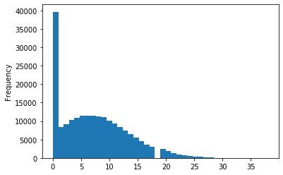

```python
calls['duration'].plot(kind='hist', bins = 40);
```

Наблюдаем звонки с нулевой продолжительностью. Это не ошибка: нулями обозначены пропущенные звонки, поэтому их не нужно удалять.

Пик значений наблюдаем диапазоне от 1 до 15 минут

### Интернет-сессии (internet)

Проверим на наличие пропусков:

```python
internet.info()
```

```
<class 'pandas.core.frame.DataFrame'>
RangeIndex: 149396 entries, 0 to 149395
Data columns (total 5 columns):
Unnamed: 0      149396 non-null int64
id              149396 non-null object
mb_used         149396 non-null float64
session_date    149396 non-null object
user_id         149396 non-null int64
dtypes: float64(1), int64(2), object(2)
memory usage: 5.7+ MB
```

Пропуски отсутствуют. `session_date` нужно перевести в формат даты

```python
internet.head()
```

|  | Unnamed: 0 | id | mb_used | session_date | user_id |
| --- | --- | --- | --- | --- | --- |
| 0 | 0 | 1000_0 | 112.95 | 2018-11-25 | 1000 |
| 1 | 1 | 1000_1 | 1052.81 | 2018-09-07 | 1000 |
| 2 | 2 | 1000_2 | 1197.26 | 2018-06-25 | 1000 |
| 3 | 3 | 1000_3 | 550.27 | 2018-08-22 | 1000 |
| 4 | 4 | 1000_4 | 302.56 | 2018-09-24 | 1000 |

```python
internet['session_date'] = pd.to_datetime(internet['session_date'], format = '%Y-%m-%d')
```

```python
internet.head()
```

|  | Unnamed: 0 | id | mb_used | session_date | user_id |
| --- | --- | --- | --- | --- | --- |
| 0 | 0 | 1000_0 | 112.95 | 2018-11-25 | 1000 |
| 1 | 1 | 1000_1 | 1052.81 | 2018-09-07 | 1000 |
| 2 | 2 | 1000_2 | 1197.26 | 2018-06-25 | 1000 |
| 3 | 3 | 1000_3 | 550.27 | 2018-08-22 | 1000 |
| 4 | 4 | 1000_4 | 302.56 | 2018-09-24 | 1000 |

Проверим `mb_used` на наличие выбросов:

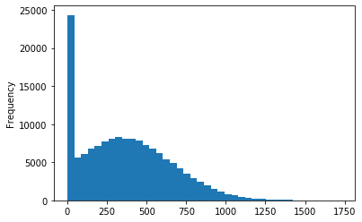

```python
internet['mb_used'].plot(kind='hist', bins = 40);
```

Удалять нулевые сессии не будем. Т.к. пользователи просто не использовали интернет на своём телефоне (возможно использовали только Wi-Fi). Оставляем

Пик значений наблюдаем диапазоне от 50 до 750мб за сессию

### Собщения (messages)

Проверяем на наличие пропусков:

```python
messages.info()
```

```
<class 'pandas.core.frame.DataFrame'>
RangeIndex: 123036 entries, 0 to 123035
Data columns (total 3 columns):
id              123036 non-null object
message_date    123036 non-null object
user_id         123036 non-null int64
dtypes: int64(1), object(2)
memory usage: 2.8+ MB
```

Пропуски отсутствуют. `message_date` перевести в формат даты

```python
messages['message_date'] = pd.to_datetime(messages['message_date'], format = '%Y-%m-%d')
```

Проверим на наличие дубликатов

```python
messages.duplicated().sum()
```

```
0
```

### Тарифы (tariffs)

```python
tariffs.info()
```

```
<class 'pandas.core.frame.DataFrame'>
RangeIndex: 2 entries, 0 to 1
Data columns (total 8 columns):
messages_included        2 non-null int64
mb_per_month_included    2 non-null int64
minutes_included         2 non-null int64
rub_monthly_fee          2 non-null int64
rub_per_gb               2 non-null int64
rub_per_message          2 non-null int64
rub_per_minute           2 non-null int64
tariff_name              2 non-null object
dtypes: int64(7), object(1)
memory usage: 256.0+ bytes
```

Здесь всё отлично

Вывод:

В таблицах `calls`,`internet`,`messages` имеются нулевые значения. Это означает, что пользователи не пользовались данным типом связи, например в последнее время вместо SMS, пользуются бесплатными сервисами обмена мгновенными сообщениями и голосовой связи.

Так же проверили на дубликаты и пропуска. Нашли ошибки в формате даты, соответственно перевели даты в нужный тип данных.

## Расчёты и добавление результатов в таблицу

### Добавим в таблицу количество сделанных звонков и израсходованных минут разговора по месяцам для каждого пользователя

Создадим столбцы с месяцами:

```python
#calls['month'] = calls['call_date'].dt.month
```

```python
# calls['call_date'].dt.date
# calls['call_date'].astype('datetime64[M]')
```

```python
#calls['call_date'] = calls['call_date'].astype('datetime64[M]')
#calls['month'] = calls['call_date'].dt.month
#calls['month_name'] = calls['call_date'].dt.month_name()
```

```python
calls.info()
```

```
<class 'pandas.core.frame.DataFrame'>
RangeIndex: 202607 entries, 0 to 202606
Data columns (total 4 columns):
id           202607 non-null object
call_date    202607 non-null datetime64[ns]
duration     202607 non-null float64
user_id      202607 non-null int64
dtypes: datetime64[ns](1), float64(1), int64(1), object(1)
memory usage: 6.2+ MB
```

```python
calls.head()
```

|  | id | call_date | duration | user_id |
| --- | --- | --- | --- | --- |
| 0 | 1000_0 | 2018-07-25 | 0.0 | 1000 |
| 1 | 1000_1 | 2018-08-17 | 0.0 | 1000 |
| 2 | 1000_2 | 2018-06-11 | 3.0 | 1000 |
| 3 | 1000_3 | 2018-09-21 | 14.0 | 1000 |
| 4 | 1000_4 | 2018-12-15 | 6.0 | 1000 |

```python
calls.rename(columns={'call_date':'month'}, inplace=True)
```

```python
month_dict = {1: 'Январь', 2: 'Февраль', 3: 'Март', 4: 'Апрель', 5: 'Май', 6: 'Июнь', 7: 'Июль', 8: 'Август', 9: 'Сентябрь', 10: 'Октябрь', 11: 'Ноябрь', 12: 'Декабрь'} #присваиваем переменной weekday_dict день недели
calls['month'] = calls['month'].map(month_dict)# присваиваем столбцу 'month' переменную
```

Посчитаем для каждого пользователя колличество использованных минут в месяц:

```python
calls = calls.groupby(['user_id', 'month']).agg({'duration': 'sum'}).reset_index()
```

Проверим:

```python
calls.info()
```

```
<class 'pandas.core.frame.DataFrame'>
RangeIndex: 0 entries
Data columns (total 3 columns):
user_id     0 non-null float64
month       0 non-null float64
duration    0 non-null float64
dtypes: float64(3)
memory usage: 124.0 bytes
```

```python
internet.head()
```

|  | Unnamed: 0 | id | mb_used | session_date | user_id |
| --- | --- | --- | --- | --- | --- |
| 0 | 0 | 1000_0 | 112.95 | 2018-11-25 | 1000 |
| 1 | 1 | 1000_1 | 1052.81 | 2018-09-07 | 1000 |
| 2 | 2 | 1000_2 | 1197.26 | 2018-06-25 | 1000 |
| 3 | 3 | 1000_3 | 550.27 | 2018-08-22 | 1000 |
| 4 | 4 | 1000_4 | 302.56 | 2018-09-24 | 1000 |

Сделаем то же самое и для инернет сессии:

```python
internet['month'] = internet['session_date'].dt.month # добавим в DF столбец 'месяц'
```

```python
internet['month'] = internet['month'].map(month_dict)
```

```python
internet = internet.groupby(['user_id', 'month']).agg({'mb_used': 'sum'}).reset_index()
```

Проверим:

```python
internet.head()
```

|  | user_id | month | mb_used |
| --- | --- | --- | --- |
| 0 | 1000 | Август | 14055.93 |
| 1 | 1000 | Декабрь | 9817.61 |
| 2 | 1000 | Июль | 14003.64 |
| 3 | 1000 | Июнь | 23233.77 |
| 4 | 1000 | Май | 2253.49 |

И посчитаем кол-во использованных сообщений в месяц:

```python
messages['month'] = messages['message_date'].dt.month
messages['month'] = messages['month'].map(month_dict)
messages = messages.groupby(['user_id','month']).agg({'message_date': 'count'}).reset_index()
messages
```

|  | user_id | month | message_date |
| --- | --- | --- | --- |
| 0 | 1000 | Август | 81 |
| 1 | 1000 | Декабрь | 70 |
| 2 | 1000 | Июль | 75 |
| 3 | 1000 | Июнь | 60 |
| 4 | 1000 | Май | 22 |
| ... | ... | ... | ... |
| 2712 | 1498 | Сентябрь | 44 |
| 2713 | 1499 | Декабрь | 66 |
| 2714 | 1499 | Ноябрь | 59 |
| 2715 | 1499 | Октябрь | 48 |
| 2716 | 1499 | Сентябрь | 11 |

2717 rows × 3 columns

### Добавим выручку с каждого пользователя

Объеденим таблицы:

```python
new_df = calls.merge(messages, on=['user_id', 'month'], how='outer')
new_df = new_df.merge(internet, on=['user_id', 'month'], how='outer')
new_df = new_df.merge(users[['user_id', 'tariff','city']], on='user_id', how='left')
tariffs.rename(columns={'tariff_name':'tariff'}, inplace=True)
new_df = new_df.merge(tariffs, on = 'tariff',how = 'left')
new_df = new_df.fillna(0)
new_df.head()
```

|  | duration | user_id | month | message_date | mb_used | tariff | city | messages_included | mb_per_month_included | minutes_included | rub_monthly_fee | rub_per_gb | rub_per_message | rub_per_minute |
| --- | --- | --- | --- | --- | --- | --- | --- | --- | --- | --- | --- | --- | --- | --- |
| 0 | 0.0 | 1000 | Август | 81.0 | 14055.93 | ultra | Краснодар | 1000 | 30720 | 3000 | 1950 | 150 | 1 | 1 |
| 1 | 0.0 | 1000 | Декабрь | 70.0 | 9817.61 | ultra | Краснодар | 1000 | 30720 | 3000 | 1950 | 150 | 1 | 1 |
| 2 | 0.0 | 1000 | Июль | 75.0 | 14003.64 | ultra | Краснодар | 1000 | 30720 | 3000 | 1950 | 150 | 1 | 1 |
| 3 | 0.0 | 1000 | Июнь | 60.0 | 23233.77 | ultra | Краснодар | 1000 | 30720 | 3000 | 1950 | 150 | 1 | 1 |
| 4 | 0.0 | 1000 | Май | 22.0 | 2253.49 | ultra | Краснодар | 1000 | 30720 | 3000 | 1950 | 150 | 1 | 1 |

```python
tariffs
```

|  | messages_included | mb_per_month_included | minutes_included | rub_monthly_fee | rub_per_gb | rub_per_message | rub_per_minute | tariff |
| --- | --- | --- | --- | --- | --- | --- | --- | --- |
| 0 | 50 | 15360 | 500 | 550 | 200 | 3 | 3 | smart |
| 1 | 1000 | 30720 | 3000 | 1950 | 150 | 1 | 1 | ultra |

Переведем из Mb в Gb (для упрощения восприятия в дальнейшем)

```python
new_df['mb_used'] = new_df['mb_used']/1024 # переводим в Gb
```

```python
new_df['mb_per_month_included'] = new_df['mb_per_month_included'] / 1024
```

```python
new_df = new_df.rename(columns= {'mb_used': 'gb_used'}) # Правильно будет переименовать столбец
```

Проверим:

```python
new_df.head()
```

|  | duration | user_id | month | message_date | gb_used | tariff | city | messages_included | mb_per_month_included | minutes_included | rub_monthly_fee | rub_per_gb | rub_per_message | rub_per_minute |
| --- | --- | --- | --- | --- | --- | --- | --- | --- | --- | --- | --- | --- | --- | --- |
| 0 | 0.0 | 1000 | Август | 81.0 | 13.726494 | ultra | Краснодар | 1000 | 30.0 | 3000 | 1950 | 150 | 1 | 1 |
| 1 | 0.0 | 1000 | Декабрь | 70.0 | 9.587510 | ultra | Краснодар | 1000 | 30.0 | 3000 | 1950 | 150 | 1 | 1 |
| 2 | 0.0 | 1000 | Июль | 75.0 | 13.675430 | ultra | Краснодар | 1000 | 30.0 | 3000 | 1950 | 150 | 1 | 1 |
| 3 | 0.0 | 1000 | Июнь | 60.0 | 22.689229 | ultra | Краснодар | 1000 | 30.0 | 3000 | 1950 | 150 | 1 | 1 |
| 4 | 0.0 | 1000 | Май | 22.0 | 2.200674 | ultra | Краснодар | 1000 | 30.0 | 3000 | 1950 | 150 | 1 | 1 |

Округлим в большую сторону. Потому-что провайдер в конце расчетного периода считает количество использованного трафика (Gb), округленного в большую сторону до целого значения

```python
new_df['gb_used'] = np.ceil(new_df['gb_used'])
```

Создадим функцию, которая считает выручку вв зависимости от тарифного плана:

```python
def payment(row_values):
    if row_values['tariff'] == 'ultra': # для тарифа ultra
        call_sum = (row_values['duration'] - row_values['minutes_included']) # считаем перерасход минут в рублях
        if call_sum <= 0:
            call_sum = 0
        else:
            call_sum = call_sum * row_values['rub_per_minute']
        message_sum = (row_values['message_date'] - row_values['messages_included']) # считаем перерасход SMS в рублях
        if message_sum <= 0:
            message_sum = 0
        else:
            message_sum = message_sum * row_values['rub_per_message']
        trafic_sum = (row_values['gb_used'] - row_values['mb_per_month_included']) # считаем перерасход трафика в рублях
        if trafic_sum <= 0:
            trafic_sum = 0
        else:
            trafic_sum = trafic_sum * row_values['rub_per_gb']
        total_sum = call_sum + message_sum + trafic_sum + row_values['rub_monthly_fee'] # суммируем перерасход + сумму тарифного плана
        return total_sum
    if row_values['tariff'] == 'smart': # то же самое и для тарифа smart
        call_sum = (row_values['duration'] - row_values['minutes_included'])
        if call_sum <= 0:
            call_sum = 0
        else:
            call_sum = call_sum * row_values['rub_per_minute']
        message_sum = (row_values['message_date'] - row_values['messages_included'])
        if message_sum <= 0:
            message_sum = 0
        else:
            message_sum = message_sum * row_values['rub_per_message']
        trafic_sum = (row_values['gb_used'] - row_values['mb_per_month_included'])
        if trafic_sum <= 0:
            trafic_sum = 0
        else:
            trafic_sum = trafic_sum * row_values['rub_per_gb']
        total_sum = call_sum + message_sum + trafic_sum + row_values['rub_monthly_fee']
        return total_sum
```

```python
new_df['total_sum']=new_df.apply(payment,axis=1) # применяем вышеописанную функцию
```

Проверим, какие суммы платят пользователи:

```python
new_df['total_sum'].value_counts(ascending=False)
```

```
1950.0    939
550.0     721
950.0     131
1150.0    120
750.0     117
         ...
2153.0      1
2831.0      1
1583.0      1
2183.0      1
3040.0      1
Name: total_sum, Length: 356, dtype: int64
```

```python
new_df.head(50) # Проверим результат
```

|  | duration | user_id | month | message_date | gb_used | tariff | city | messages_included | mb_per_month_included | minutes_included | rub_monthly_fee | rub_per_gb | rub_per_message | rub_per_minute | total_sum |
| --- | --- | --- | --- | --- | --- | --- | --- | --- | --- | --- | --- | --- | --- | --- | --- |
| 0 | 0.0 | 1000 | Август | 81.0 | 14.0 | ultra | Краснодар | 1000 | 30.0 | 3000 | 1950 | 150 | 1 | 1 | 1950.0 |
| 1 | 0.0 | 1000 | Декабрь | 70.0 | 10.0 | ultra | Краснодар | 1000 | 30.0 | 3000 | 1950 | 150 | 1 | 1 | 1950.0 |
| 2 | 0.0 | 1000 | Июль | 75.0 | 14.0 | ultra | Краснодар | 1000 | 30.0 | 3000 | 1950 | 150 | 1 | 1 | 1950.0 |
| 3 | 0.0 | 1000 | Июнь | 60.0 | 23.0 | ultra | Краснодар | 1000 | 30.0 | 3000 | 1950 | 150 | 1 | 1 | 1950.0 |
| 4 | 0.0 | 1000 | Май | 22.0 | 3.0 | ultra | Краснодар | 1000 | 30.0 | 3000 | 1950 | 150 | 1 | 1 | 1950.0 |
| 5 | 0.0 | 1000 | Ноябрь | 58.0 | 15.0 | ultra | Краснодар | 1000 | 30.0 | 3000 | 1950 | 150 | 1 | 1 | 1950.0 |
| 6 | 0.0 | 1000 | Октябрь | 73.0 | 15.0 | ultra | Краснодар | 1000 | 30.0 | 3000 | 1950 | 150 | 1 | 1 | 1950.0 |
| 7 | 0.0 | 1000 | Сентябрь | 57.0 | 15.0 | ultra | Краснодар | 1000 | 30.0 | 3000 | 1950 | 150 | 1 | 1 | 1950.0 |
| 8 | 0.0 | 1002 | Август | 13.0 | 20.0 | smart | Стерлитамак | 50 | 15.0 | 500 | 550 | 200 | 3 | 3 | 1550.0 |
| 9 | 0.0 | 1002 | Декабрь | 12.0 | 18.0 | smart | Стерлитамак | 50 | 15.0 | 500 | 550 | 200 | 3 | 3 | 1150.0 |
| 10 | 0.0 | 1002 | Июль | 11.0 | 18.0 | smart | Стерлитамак | 50 | 15.0 | 500 | 550 | 200 | 3 | 3 | 1150.0 |
| 11 | 0.0 | 1002 | Июнь | 4.0 | 11.0 | smart | Стерлитамак | 50 | 15.0 | 500 | 550 | 200 | 3 | 3 | 550.0 |
| 12 | 0.0 | 1002 | Ноябрь | 16.0 | 19.0 | smart | Стерлитамак | 50 | 15.0 | 500 | 550 | 200 | 3 | 3 | 1350.0 |
| 13 | 0.0 | 1002 | Октябрь | 10.0 | 14.0 | smart | Стерлитамак | 50 | 15.0 | 500 | 550 | 200 | 3 | 3 | 550.0 |
| 14 | 0.0 | 1002 | Сентябрь | 4.0 | 17.0 | smart | Стерлитамак | 50 | 15.0 | 500 | 550 | 200 | 3 | 3 | 950.0 |
| 15 | 0.0 | 1003 | Август | 37.0 | 9.0 | ultra | Москва | 1000 | 30.0 | 3000 | 1950 | 150 | 1 | 1 | 1950.0 |
| 16 | 0.0 | 1003 | Декабрь | 75.0 | 10.0 | ultra | Москва | 1000 | 30.0 | 3000 | 1950 | 150 | 1 | 1 | 1950.0 |
| 17 | 0.0 | 1003 | Ноябрь | 94.0 | 12.0 | ultra | Москва | 1000 | 30.0 | 3000 | 1950 | 150 | 1 | 1 | 1950.0 |
| 18 | 0.0 | 1003 | Октябрь | 83.0 | 15.0 | ultra | Москва | 1000 | 30.0 | 3000 | 1950 | 150 | 1 | 1 | 1950.0 |
| 19 | 0.0 | 1003 | Сентябрь | 91.0 | 13.0 | ultra | Москва | 1000 | 30.0 | 3000 | 1950 | 150 | 1 | 1 | 1950.0 |
| 20 | 0.0 | 1004 | Август | 151.0 | 28.0 | ultra | Новокузнецк | 1000 | 30.0 | 3000 | 1950 | 150 | 1 | 1 | 1950.0 |
| 21 | 0.0 | 1004 | Декабрь | 162.0 | 18.0 | ultra | Новокузнецк | 1000 | 30.0 | 3000 | 1950 | 150 | 1 | 1 | 1950.0 |
| 22 | 0.0 | 1004 | Июль | 181.0 | 22.0 | ultra | Новокузнецк | 1000 | 30.0 | 3000 | 1950 | 150 | 1 | 1 | 1950.0 |
| 23 | 0.0 | 1004 | Июнь | 134.0 | 18.0 | ultra | Новокузнецк | 1000 | 30.0 | 3000 | 1950 | 150 | 1 | 1 | 1950.0 |
| 24 | 0.0 | 1004 | Май | 95.0 | 14.0 | ultra | Новокузнецк | 1000 | 30.0 | 3000 | 1950 | 150 | 1 | 1 | 1950.0 |
| 25 | 0.0 | 1004 | Ноябрь | 158.0 | 16.0 | ultra | Новокузнецк | 1000 | 30.0 | 3000 | 1950 | 150 | 1 | 1 | 1950.0 |
| 26 | 0.0 | 1004 | Октябрь | 165.0 | 19.0 | ultra | Новокузнецк | 1000 | 30.0 | 3000 | 1950 | 150 | 1 | 1 | 1950.0 |
| 27 | 0.0 | 1004 | Сентябрь | 146.0 | 15.0 | ultra | Новокузнецк | 1000 | 30.0 | 3000 | 1950 | 150 | 1 | 1 | 1950.0 |
| 28 | 0.0 | 1005 | Август | 64.0 | 8.0 | smart | Набережные Челны | 50 | 15.0 | 500 | 550 | 200 | 3 | 3 | 592.0 |
| 29 | 0.0 | 1005 | Апрель | 41.0 | 10.0 | smart | Набережные Челны | 50 | 15.0 | 500 | 550 | 200 | 3 | 3 | 550.0 |
| 30 | 0.0 | 1005 | Декабрь | 54.0 | 9.0 | smart | Набережные Челны | 50 | 15.0 | 500 | 550 | 200 | 3 | 3 | 562.0 |
| 31 | 0.0 | 1005 | Июль | 56.0 | 8.0 | smart | Набережные Челны | 50 | 15.0 | 500 | 550 | 200 | 3 | 3 | 568.0 |
| 32 | 0.0 | 1005 | Июнь | 47.0 | 10.0 | smart | Набережные Челны | 50 | 15.0 | 500 | 550 | 200 | 3 | 3 | 550.0 |
| 33 | 0.0 | 1005 | Май | 42.0 | 8.0 | smart | Набережные Челны | 50 | 15.0 | 500 | 550 | 200 | 3 | 3 | 550.0 |
| 34 | 0.0 | 1005 | Март | 56.0 | 11.0 | smart | Набережные Челны | 50 | 15.0 | 500 | 550 | 200 | 3 | 3 | 568.0 |
| 35 | 0.0 | 1005 | Ноябрь | 51.0 | 13.0 | smart | Набережные Челны | 50 | 15.0 | 500 | 550 | 200 | 3 | 3 | 553.0 |
| 36 | 0.0 | 1005 | Октябрь | 44.0 | 8.0 | smart | Набережные Челны | 50 | 15.0 | 500 | 550 | 200 | 3 | 3 | 550.0 |
| 37 | 0.0 | 1005 | Сентябрь | 52.0 | 7.0 | smart | Набережные Челны | 50 | 15.0 | 500 | 550 | 200 | 3 | 3 | 556.0 |
| 38 | 0.0 | 1005 | Февраль | 38.0 | 8.0 | smart | Набережные Челны | 50 | 15.0 | 500 | 550 | 200 | 3 | 3 | 550.0 |
| 39 | 0.0 | 1005 | Январь | 7.0 | 3.0 | smart | Набережные Челны | 50 | 15.0 | 500 | 550 | 200 | 3 | 3 | 550.0 |
| 40 | 0.0 | 1007 | Август | 27.0 | 21.0 | smart | Москва | 50 | 15.0 | 500 | 550 | 200 | 3 | 3 | 1750.0 |
| 41 | 0.0 | 1007 | Апрель | 11.0 | 8.0 | smart | Москва | 50 | 15.0 | 500 | 550 | 200 | 3 | 3 | 550.0 |
| 42 | 0.0 | 1007 | Декабрь | 26.0 | 13.0 | smart | Москва | 50 | 15.0 | 500 | 550 | 200 | 3 | 3 | 550.0 |
| 43 | 0.0 | 1007 | Июль | 26.0 | 16.0 | smart | Москва | 50 | 15.0 | 500 | 550 | 200 | 3 | 3 | 750.0 |
| 44 | 0.0 | 1007 | Июнь | 26.0 | 14.0 | smart | Москва | 50 | 15.0 | 500 | 550 | 200 | 3 | 3 | 550.0 |
| 45 | 0.0 | 1007 | Май | 39.0 | 18.0 | smart | Москва | 50 | 15.0 | 500 | 550 | 200 | 3 | 3 | 1150.0 |
| 46 | 0.0 | 1007 | Ноябрь | 21.0 | 16.0 | smart | Москва | 50 | 15.0 | 500 | 550 | 200 | 3 | 3 | 750.0 |
| 47 | 0.0 | 1007 | Октябрь | 18.0 | 15.0 | smart | Москва | 50 | 15.0 | 500 | 550 | 200 | 3 | 3 | 550.0 |
| 48 | 0.0 | 1007 | Сентябрь | 31.0 | 13.0 | smart | Москва | 50 | 15.0 | 500 | 550 | 200 | 3 | 3 | 550.0 |
| 49 | 0.0 | 1008 | Декабрь | 56.0 | 13.0 | smart | Челябинск | 50 | 15.0 | 500 | 550 | 200 | 3 | 3 | 568.0 |

## Анализ данных

### Сколько минут / сообщений / трафика требуется пользователям каждого тарифа в месяц

Создадим новый DataFrame, со срезом по тарифу `smart`

```python
tariff_smart = new_df.query('tariff=="smart"')
```

Создадим новый DataFrame, со срезом по тарифу `ultra`

```python
tariff_ultra = new_df.query('tariff=="ultra"')
```

```python
tariff_ultra['total_sum'].value_counts()
```

```
1950.0    851
2250.0     21
2400.0     18
2550.0     13
2100.0     12
2700.0     10
3000.0     10
3300.0      9
3150.0      9
3750.0      9
2850.0      7
3900.0      6
3450.0      4
3600.0      2
4200.0      1
4650.0      1
4050.0      1
4800.0      1
Name: total_sum, dtype: int64
```

### Вычисления для тарифа smart

Посчитаем дисперсию и стандарт отклонение минут для тарифа smart:

```python
print('среднее кол-во минут для smart:', tariff_smart['duration'].mean())
x=tariff_smart['duration']
variance_smart_min = np.var(x, ddof=1) # ddof = 1, т.к. это выборка
print('дисперсия минут для smart:', variance_smart_min)
standart_smart_min = np.sqrt(variance_smart_min)
print('стандарт отклонение минут для smart:', standart_smart_min)
```

```
среднее кол-во минут для smart: 0.0
дисперсия минут для smart: 0.0
стандарт отклонение минут для smart: 0.0
```

Построим гистограмму:

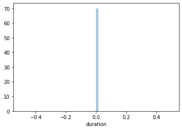

```python
sns.distplot(tariff_smart['duration'],bins=70); # гистограмма минут смарт
```

Посчитаем дисперсию и стандарт отклонение для SMS тарифа `smart`:

```python
print('среднее кол-во смс для smart:', tariff_smart['message_date'].mean())
x=tariff_smart['message_date']
variance_smart_sms = np.var(x, ddof=1) # ddof = 1, т.к. это выборка
print('дисперсия смс для smart:', variance_smart_sms)
standart_smart_sms = np.sqrt(variance_smart_sms)
print('стандарт отклонение смс для smart:', standart_smart_sms)
```

```
среднее кол-во смс для smart: 33.384028712427096
дисперсия смс для smart: 796.8129584480083
стандарт отклонение смс для smart: 28.22787555676141
```

Построим гистограмму:

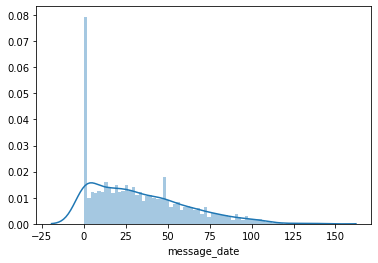

```python
sns.distplot(tariff_smart['message_date'],bins=70); # гистограмма смс по месяцам смарт
```

По гистограмме можно сделать вывод о том, что пользователи расходуют от 0 до 100 sms в месяц, далее линия сливается с нулем. Пик графика наблюдается на отметке 0 и 50.

Посчитаем дисперсию и стандарт отклонение для траффика тарифа `smart`:

```python
print('среднее кол-во трафика в Гб для smart:', tariff_smart['gb_used'].mean())
x=tariff_smart['gb_used']
variance_smart_traffic = np.var(x, ddof=1) # ddof = 1, т.к. это выборка
print('дисперсия трафика для smart:', variance_smart_traffic)
standart_smart_traffic = np.sqrt(variance_smart_traffic)
print('стандарт отклонение трафика для smart:', standart_smart_traffic)
```

```
среднее кол-во трафика в Гб для smart: 16.328847016599372
дисперсия трафика для smart: 33.02870517811161
стандарт отклонение трафика для smart: 5.7470605685090534
```

Построим гистограмму:

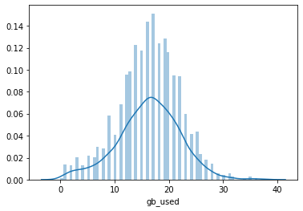

```python
sns.distplot(tariff_smart['gb_used'],bins=70); # гистограмма инэта по месяцам в среднем смарт
```

Основной расход трафика приходится в диапазоне от 8 до 25 Gb за расчетный период. Пик наблюдаем на отметке в 16 Gb.

### Вычисления для тарифа ultra

Посчитаем дисперсию и стандарт отклонение для минут для тарифа `ultra`:

```python
print('среднее кол-во минут для ultra:', tariff_ultra['duration'].mean())
x=tariff_ultra['duration']
variance_ultra_min = np.var(x, ddof=1) # ddof = 1, т.к. это выборка
print('дисперсия минут для ultra:', variance_ultra_min)
standart_ultra_min = np.sqrt(variance_ultra_min)
print('стандарт отклонение минут для ultra:', standart_ultra_min)
```

```
среднее кол-во минут для ultra: 0.0
дисперсия минут для ultra: 0.0
стандарт отклонение минут для ultra: 0.0
```

Построим гитограмму:

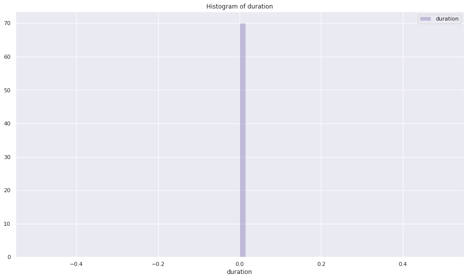

```python
plt.figure(figsize=(16,9))
sns.set()

sns.distplot(tariff_ultra["duration"],color="m",label="duration",bins=70,)

plt.title("Histogram of duration")
plt.legend();
```

Посчитаем дисперсию и стандарт отклонение для SMS тарифа `ultra`:

```python
print('среднее кол-во смс для ultra:', tariff_ultra['message_date'].mean())
x=tariff_ultra['message_date']
variance_ultra_sms = np.var(x, ddof=1) # ddof = 1, т.к. это выборка
print('дисперсия смс для ultra:', variance_ultra_sms)
standart_ultra_sms = np.sqrt(variance_ultra_sms)
print('стандарт отклонение смс для ultra:', standart_ultra_sms)
```

```
среднее кол-во смс для ultra: 49.36345177664975
дисперсия смс для ultra: 2285.266142544674
стандарт отклонение смс для ultra: 47.80445735017472
```

Построим гистограмму:

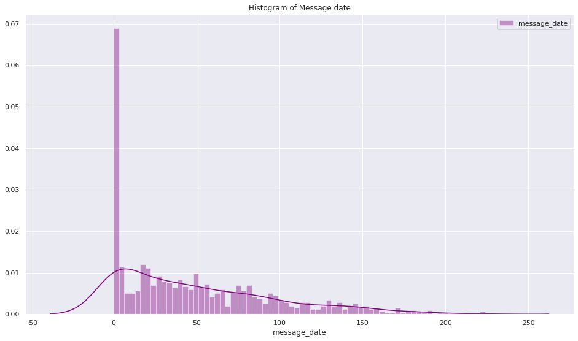

```python
plt.figure(figsize=(16,9))
sns.set()

sns.distplot(tariff_ultra["message_date"],color="purple",label="message_date",bins=70,)

plt.title("Histogram of Message date")
plt.legend();
```

Посчитаем дисперсию и стандарт отклонение интернет-траффика для тарифа `ultra`:

```python
print('среднее кол-во трафика для ultra:', tariff_ultra['gb_used'].mean())
x=tariff_ultra['gb_used']
variance_ultra_traffic = np.var(x, ddof=1) # ddof = 1, т.к. это выборка
print('дисперсия трафика для ultra:', variance_ultra_traffic)
standart_ultra_traffic = np.sqrt(variance_ultra_traffic)
print('стандарт отклонение трафика для ultra:', standart_ultra_traffic)
```

```
среднее кол-во трафика для ultra: 19.494416243654822
дисперсия трафика для ultra: 97.09168626965459
стандарт отклонение трафика для ultra: 9.853511367510293
```

Построим гистограмму:

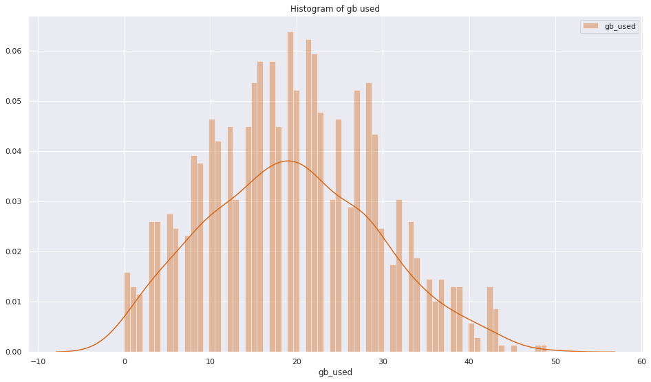

```python
plt.figure(figsize=(16,9))
sns.set()


sns.distplot(tariff_ultra["gb_used"],color="chocolate",label="gb_used",bins=70,);

plt.title("Histogram of gb used")
plt.legend(); # гистограмма траффика ultra
```

Основной расход трафика приходится в диапазоне от 1 до 43 Gb за расчетный период. Пик наблюдаем на отметке в ~20 Gb.

Вывод: Пользователи тарифа `ultra` используют больше трафика, чем пользователи тарифа `smart`. Тем самым пользователи более дорогово тарифного плана, более заинтересованы в интернет-сёрфинге.

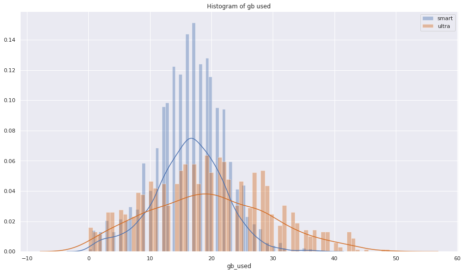

```python
plt.figure(figsize=(16,9))
sns.set()
sns.distplot(tariff_smart['gb_used'],bins=70, label='smart')

sns.distplot(tariff_ultra["gb_used"],color="chocolate",label="ultra",bins=70)

plt.title("Histogram of gb used")
plt.legend(); # гистограмма траффика ultra
```

## Проверка гипотез

### средняя выручка пользователей тарифов «Ультра» и «Смарт» различаются;

Первым делом составим нулевую и альтернативную гипотезы.

H₀(нулевая гипотеза) всегда формулируется так, что иcпользовать знак равенства(=).

- H₀ - средняя выручка пользователей тарифов «Ультра» и «Смарт» равна
- H₁ - средняя выручка пользователей тарифов «Ультра» и «Смарт» не равна

Cравним дисперсии общей выручки для обоих тарифов:

```python
x=tariff_smart['total_sum']
variance_smart_sum = np.var(x, ddof=1) # ddof = 1, т.к. это выборка
print('Дисперсия суммы для smart:', variance_smart_sum)
```

```
Дисперсия суммы для smart: 548424.3134453383
```

```python
x=tariff_ultra['total_sum']
variance_ultra_sum = np.var(x, ddof=1) # ddof = 1, т.к. это выборка
print('Дисперсия суммы для ultra:', variance_ultra_sum)
```

```
Дисперсия суммы для ultra: 141516.7450786183
```

equal_var - необязательный параметр, задающий считать ли равными дисперсии генеральных совокупностей, из которых были сформированы выборки.

Т.к. дисперсии разные, значит параметр `equal_var = False` (не считать)

```python
sample1 = tariff_smart['total_sum']
sample2 = tariff_ultra['total_sum']
alpha = 0.05
results = st.ttest_ind(sample1, sample2, equal_var = False)
print('p_значение', results.pvalue)
if results.pvalue < alpha:
    print('Отвергаем H₀')
else:
    print('Не получилось отвергнуть нулевую гипотезу')
print('Средняя выручка с клиента для тарифа smart:',tariff_smart['total_sum'].mean().round(0))
print('Средняя выручка с клиента для тарифа ultra:',tariff_ultra['total_sum'].mean().round(0))
```

```
p_значение 0.0
Отвергаем H₀
Средняя выручка с клиента для тарифа smart: 1165.0
Средняя выручка с клиента для тарифа ultra: 2070.0
```

Отвергаем нулевую гипотезу о том, что средняя выручка между пользователями тарифа равна.

### средняя выручка пользователей из Москвы отличается от выручки пользователей из других регионов.

- H₀ - средняя выручка пользователей из Москвы не отличается от выручки пользователей из других регионов
- H₁ - средняя выручка пользователей из Москвы отличается от выручки пользователей из других регионов

```python
sample_1 = new_df[new_df['city']=='Москва']['total_sum']
sample_2 = new_df[new_df['city']!='Москва']['total_sum']
alpha = 0.05
results = st.ttest_ind(sample_1, sample_2,equal_var=False)
print('p_значение', results.pvalue)
if results.pvalue < alpha:
    print('Отвергаем H₀')
else:
    print('Не получилось отвергнуть нулевую гипотезу')
print('Средняя выручка пользователей из Москвы:', sample_1.mean().round(0))
print('Средняя выручка пользователей из дургих регионов:',sample_2.mean().round(0))
```

```
p_значение 0.2843727016644021
Не получилось отвергнуть нулевую гипотезу
Средняя выручка пользователей из Москвы: 1472.0
Средняя выручка пользователей из дургих регионов: 1436.0
```

Вывод: Попадание или непопадание значения, посчитанного по выборке, в критический интервал - не повод считать, что наши гипотезы доказаны или нет. Иными словами, мы не принимаем H₀(нулевую гипотезу). Данные лишь могут дать нам основания отвергнуть(или нет) H₀.

Для проверки гипотез, был выбран метод `scipy.stats.ttest_ind(array1,array2)`. Т.к. у нас есть основание полагать, что выборки взяты из схожих по параметрам совокупностей. А так же, нам нужен этот метод, для того, чтобы получить более точные результаты.

## Общий вывод

Подведём итог:

Гипотеза о разницы выручки между столицей и регионами отвергнута. Следственно поведение клиентов "Мегалайна" - эквивалентны.

**При работе с дасетом были выполнены следующие действия:**

Предварительно изучив полученные данные, мы почти не выявили пропусков(кроме обоснованных). Заменять и удалять данные не пришлось за отсутствием необходимости.